# Importing publicly available data

Mark Dunning; mark ‘dot’ dunning ‘at’ cruk.cam.ac.uk, Oscar Rueda; oscar ‘dot’ rueda ‘at’ cruk.cam.ac.uk

Last modified: 14 Feb 2016

# Bioconductor data packages

The bioconductor project includes a collection of [Experimental Data](http://bioconductor.org/packages/release/BiocViews.html#___ExperimentData) packages that can be downloaded and installed in the same way as regular software packages in Bioconductor

## Example data for a package

The size limit for a new package submission is quite restrictive, so authors often have to submit example datasets separately. e.g. The [beadrrayExampleData](http://bioconductor.org/packages/release/data/experiment/html/beadarrayExampleData.html) has example data which can be used to test examples from the beadarray package

## Supplementary data for a paper

e.g. from the [Markowetz lab @ CI](http://bioconductor.org/packages/release/data/experiment/html/Fletcher2013a.html). This package not only has the data, but R scripts to reproduce the analysis in the paper.

## Curated datasets for meta-analysis

Several breast cancer datasets have been curated for use with the genefu package; which has many useful functions for classication of breast cancer

- [breastCancerNKI](http://bioconductor.org/packages/release/data/experiment/html/breastCancerNKI.html)
- [breastCancerVDX](http://bioconductor.org/packages/release/data/experiment/html/breastCancerVDX.html)

```r
source("http://www.bioconductor.org/biocLite.R")
biocLite("breastCancerNKI")
biocLite("breastCancerVDX")
```

also

- [curatedBreastData](http://bioconductor.org/packages/release/data/experiment/html/curatedBreastData.html)
- [curatedBladderData](http://bioconductor.org/packages/release/data/experiment/html/curatedBladderData.html)
- [curatedOvarianData](http://bioconductor.org/packages/release/data/experiment/html/curatedOvarianData.html)

# Data from Gene Expression Omnibus (GEO)

## Using the GEOquery package

Can search from GEO [home page](http://www.ncbi.nlm.nih.gov/geo/) or using this [Shiny app](https://zhiji.shinyapps.io/GEOsearch) to get a dataset ID which will be of the form **GSE….**.

With this identifier, we can use the [GEOquery](http://bioinformatics.oxfordjournals.org/content/23/14/1846.long) Bioconductor package

```r
library(GEOquery)
```

## Example. General procedure

Lets say we have identified a dataset which has leukemia patients. The web page describing these data is [here](http://www.ncbi.nlm.nih.gov/geo/query/acc.cgi?acc=GSE1729). The main function we need to use is `getGEO`. This downloads the *series* file for the dataset and parses the data in this file into a format that is compatible with Bioconductor.

```r
mydata <- getGEO("GSE1729")
mydata
```

sometimes datasets in GEO can include more than one platform (technology) so the result is returned in the form of a list; one item in the list for each platform. In this case, even though there is only one platform used, we have to subset the object.

```r
mydata[[1]]
```

*The recommended approach* is to download to disk first. On the [page](http://www.ncbi.nlm.nih.gov/geo/query/acc.cgi?acc=GSE1729) for the dataset you should see there is a link to the **Series Matrix File(s)**. You can copy and paste this link into R and use the `download.file` function to get data from the URL to disk. GEOquery is then able to read from this file in future using the filename argument.

Advantage is that you don’t need an internet connection to run your script

```r
remotefile <- 'ftp://ftp.ncbi.nlm.nih.gov/geo/series/GSE1nnn/GSE1729/matrix/GSE1729_series_matrix.txt.gz'
destfile <- "data/GSE1729_series_matrix.txt.gz"
if(!file.exists(destfile)) download.file(remotefile, destfile)
mydata <- getGEO(filename="data/GSE1729_series_matrix.txt.gz")
```

```
## File stored at:
## /var/folders/b8/q7k4zz6d3x5bxrgwmst1vmmhdbgdr4/T//RtmpZkhjDc/GPL96.soft
```

```r
mydata
```

```
## ExpressionSet (storageMode: lockedEnvironment)
## assayData: 22283 features, 43 samples
##   element names: exprs
## protocolData: none
## phenoData
##   sampleNames: GSM30279 GSM30280 ... GSM30321 (43 total)
##   varLabels: title geo_accession ... data_row_count (26 total)
##   varMetadata: labelDescription
## featureData
##   featureNames: 1007_s_at 1053_at ... AFFX-TrpnX-M_at (22283
##     total)
##   fvarLabels: ID GB_ACC ... Gene Ontology Molecular Function (16
##     total)
##   fvarMetadata: Column Description labelDescription
## experimentData: use 'experimentData(object)'
## Annotation: GPL96
```

The structure of the `mydata` object should be quite familiar to you. The expression values can be retrieved by the `exprs` function. Here, we just print the first 5 rows and 5 columns. In total there are 22283 rows (genes) and 43 columns (samples)

## Q. What scale are the expression values recorded on? Is this an appropriate scale for analysis / visualisation?

```r
exprs(mydata)[1:5,1:5]
```

```
##           GSM30279 GSM30280 GSM30281 GSM30282 GSM30283
## 1007_s_at     71.0     55.4     32.6     27.7     13.5
## 1053_at       89.5     59.8     50.2     67.3     63.1
## 117_at        41.7     24.6     40.1     21.4      8.5
## 121_at       369.6    265.4    264.8    164.0    156.1
## 1255_g_at     19.7     13.8      2.3      2.9      2.6
```

```r
summary(exprs(mydata)[,1:5])
```

```
##     GSM30279          GSM30280          GSM30281         GSM30282
##  Min.   :    0.2   Min.   :    0.1   Min.   :   0.1   Min.   :   0.1
##  1st Qu.:   13.3   1st Qu.:    9.6   1st Qu.:   9.6   1st Qu.:   8.4
##  Median :   43.3   Median :   32.2   Median :  34.4   Median :  28.2
##  Mean   :  184.2   Mean   :  187.3   Mean   : 175.4   Mean   : 175.4
##  3rd Qu.:  114.2   3rd Qu.:  100.8   3rd Qu.: 109.2   3rd Qu.: 103.0
##  Max.   :14225.6   Max.   :11934.2   Max.   :9270.5   Max.   :9905.0
##     GSM30283
##  Min.   :   0.1
##  1st Qu.:   7.2
##  Median :  26.0
##  Mean   : 166.6
##  3rd Qu.: 105.1
##  Max.   :8805.2
```

We can visualise the expression values for a particular gene by knowing which row of the expression matrix it is found in.

```r
exprs(mydata)[1,]
```

```
## GSM30279 GSM30280 GSM30281 GSM30282 GSM30283 GSM30284 GSM30285 GSM30286
##     71.0     55.4     32.6     27.7     13.5     44.5     18.9     54.8
## GSM30287 GSM30288 GSM30289 GSM30290 GSM30291 GSM30292 GSM30293 GSM30294
##     37.7     48.1     35.2     50.8     20.5     69.8     60.4     66.8
## GSM30295 GSM30296 GSM30297 GSM30298 GSM30299 GSM30300 GSM30301 GSM30302
##     46.8     59.5     66.9     37.4      4.8     34.9     47.7    150.1
## GSM30303 GSM30304 GSM30305 GSM30306 GSM30307 GSM30308 GSM30309 GSM30310
##     55.7     82.7     54.4     37.8     71.6     81.9     86.0     57.9
## GSM30311 GSM30312 GSM30313 GSM30314 GSM30315 GSM30316 GSM30317 GSM30318
##     90.7     15.0     34.7     98.9     67.4     63.0     62.7    142.8
## GSM30319 GSM30320 GSM30321
##     20.6     67.6     84.8
```

```r
fData(mydata)[1,1:8]
```

```
##                  ID GB_ACC SPOT_ID Species Scientific Name Annotation Date
## 1007_s_at 1007_s_at U48705    <NA>            Homo sapiens     Jun 9, 2011
##               Sequence Type                 Sequence Source
## 1007_s_at Exemplar sequence Affymetrix Proprietary Database
##                                                                                        Target Description
## 1007_s_at U48705 /FEATURE=mRNA /DEFINITION=HSU48705 Human receptor tyrosine kinase DDR gene, complete cds
```

## Example. Quality assessment of the downloaded data

As we have downloaded the processed and normalised data, there are limited options in terms of quality assessment. Without the *.cel* files we cannot examine the raw images or fit PLMs. The simplest form of QA is the boxplot.

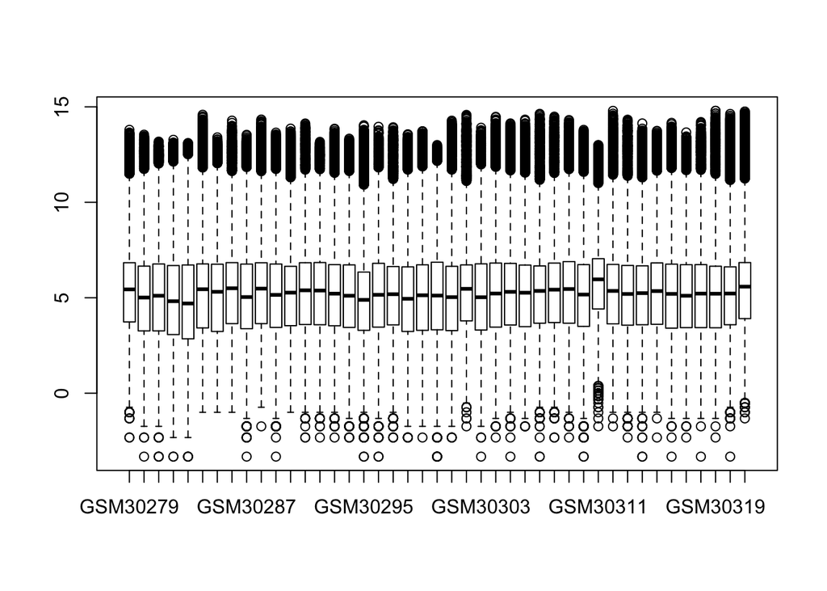

```r
boxplot(log2(exprs(mydata)))
```

The *arrayQualityMetrics* package can automatically-generate a variety of QA plots. It incorporates clustering methods that we will explore in-depth later in the course. Such methods are extremely useful for verifying known relationships between sample groups.

## Q. Generate an arrayQualityMetrics report for the dataset. Do any arrays seem to be poor quality?

The report should be generated in a folder called `arrayQualityMetrics report for mydata` (the name of the directory can be configured).

N.B the `force=TRUE` argument will make sure that the output gets written if the specified directory name already exists ******

```r
library(arrayQualityMetrics)
arrayQualityMetrics(mydata, force=TRUE)
```

We can remove samples from our `ExpressionSet` object using the same subsetting rules that apply when removing columns from a matrix or data frame. Consider the following example; whereas `a[,1]` prints the first column, `a[,-1]` prints the matrix with all columns *except* the first one.

```r
a <- matrix(rnorm(100),ncol=10)
colnames(a) <- LETTERS[1:10]
a[,1]
```

```
##  [1] -1.5189953  0.3584195 -0.7744410  1.3356705  0.9389140 -1.5673945
##  [7]  0.3485802  1.9000448  0.1720101 -0.1494207
```

```r
a[,-1]
```

```
##                 B          C           D           E          F
##  [1,]  0.09209687 -0.9450521 -0.54898344  0.95450804  0.1348013
##  [2,]  1.07379456 -1.4947641 -0.23176477  0.49207319 -0.4615613
##  [3,] -0.62187103 -0.6802949  0.66454501 -0.92035985  1.1930635
##  [4,]  0.03406120 -0.4728990 -0.09736152 -0.11111513 -0.4390230
##  [5,] -0.75330506  0.1087952 -0.41619025  0.04675134  2.0533174
##  [6,]  2.12959436  0.9924733  0.23844057 -0.53182745 -0.7115075
##  [7,]  1.07027137  1.2974078  0.58609973 -1.61658088 -1.1984138
##  [8,]  1.02323389 -0.1714760  1.28811749  0.73795112 -0.5526200
##  [9,] -0.66956038  1.3420854  0.36283210  0.52085653  0.9728858
## [10,]  2.05279710  0.1083092 -0.62635820  0.55818257  0.7077582
##                 G          H          I          J
##  [1,]  1.60887872 -0.8120257 -0.1408406  1.1091033
##  [2,]  0.01784353 -1.5496241  0.3706185  0.5093582
##  [3,]  0.68616713 -1.0739613  0.7198489 -0.4059869
##  [4,] -0.78248181 -1.8551048  0.2271309 -0.6495296
##  [5,] -0.14320712 -1.6711934  0.6582905  1.0174476
##  [6,]  0.54038933 -1.0907873 -0.8990274 -0.6118023
##  [7,]  0.44393467  0.6758575 -0.5586434  1.8964696
##  [8,]  0.27927406  0.2200853 -0.1337276 -2.0531659
##  [9,] -0.39328230  1.9153863 -1.3334805 -0.5410945
## [10,]  0.23911269 -1.0006950 -2.0410785 -0.5074739
```

The same technique applies to vectors with more than one element

```r
a[,c(1,10)]
```

```
##                A          J
##  [1,] -1.5189953  1.1091033
##  [2,]  0.3584195  0.5093582
##  [3,] -0.7744410 -0.4059869
##  [4,]  1.3356705 -0.6495296
##  [5,]  0.9389140  1.0174476
##  [6,] -1.5673945 -0.6118023
##  [7,]  0.3485802  1.8964696
##  [8,]  1.9000448 -2.0531659
##  [9,]  0.1720101 -0.5410945
## [10,] -0.1494207 -0.5074739
```

```r
a[,-c(1,10)]
```

```
##                 B          C           D           E          F
##  [1,]  0.09209687 -0.9450521 -0.54898344  0.95450804  0.1348013
##  [2,]  1.07379456 -1.4947641 -0.23176477  0.49207319 -0.4615613
##  [3,] -0.62187103 -0.6802949  0.66454501 -0.92035985  1.1930635
##  [4,]  0.03406120 -0.4728990 -0.09736152 -0.11111513 -0.4390230
##  [5,] -0.75330506  0.1087952 -0.41619025  0.04675134  2.0533174
##  [6,]  2.12959436  0.9924733  0.23844057 -0.53182745 -0.7115075
##  [7,]  1.07027137  1.2974078  0.58609973 -1.61658088 -1.1984138
##  [8,]  1.02323389 -0.1714760  1.28811749  0.73795112 -0.5526200
##  [9,] -0.66956038  1.3420854  0.36283210  0.52085653  0.9728858
## [10,]  2.05279710  0.1083092 -0.62635820  0.55818257  0.7077582
##                 G          H          I
##  [1,]  1.60887872 -0.8120257 -0.1408406
##  [2,]  0.01784353 -1.5496241  0.3706185
##  [3,]  0.68616713 -1.0739613  0.7198489
##  [4,] -0.78248181 -1.8551048  0.2271309
##  [5,] -0.14320712 -1.6711934  0.6582905
##  [6,]  0.54038933 -1.0907873 -0.8990274
##  [7,]  0.44393467  0.6758575 -0.5586434
##  [8,]  0.27927406  0.2200853 -0.1337276
##  [9,] -0.39328230  1.9153863 -1.3334805
## [10,]  0.23911269 -1.0006950 -2.0410785
```

The `ExpressionSet` object has been design to respect these same subsetting rules, even though it is an inherently more-complicated object.

In the following we create a new object that represents the first four *samples* in the object. This is especially neat, as it creates a subset of the expression matrix and phenotypic data in the same operation. At the same time, the number of genes is not affected.

```r
subset <- mydata[,1:4]
dim(exprs(subset))
```

```
## [1] 22283     4
```

```r
dim(pData(subset))
```

```
## [1]  4 26
```

```r
subset <- mydata[,-c(1,4)]
subset
```

```
## ExpressionSet (storageMode: lockedEnvironment)
## assayData: 22283 features, 41 samples
##   element names: exprs
## protocolData: none
## phenoData
##   sampleNames: GSM30280 GSM30281 ... GSM30321 (41 total)
##   varLabels: title geo_accession ... data_row_count (26 total)
##   varMetadata: labelDescription
## featureData
##   featureNames: 1007_s_at 1053_at ... AFFX-TrpnX-M_at (22283
##     total)
##   fvarLabels: ID GB_ACC ... Gene Ontology Molecular Function (16
##     total)
##   fvarMetadata: Column Description labelDescription
## experimentData: use 'experimentData(object)'
## Annotation: GPL96
```

So in order to remove one or more poor-quality arrays we need to know their indices.

## Q. Now create a new dataset with the poor quality arrays removed

Finally, when creating a subset of an `ExpressionSet` object, we can also filter on rows. e.g. to select the first 100 genes.

```r
subset <- mydata[1:100,]
```

In the next section we will look into the annotation of the dataset in more detail

## Example. Dealing with gene annotation

The annotation for the features can be retrieved by using `fData`. Because of the strict submission process, all the rows of this feature matrix are in the same order as the expression matrix; which greatly-simplifies further analysis

```r
fData(mydata)[1:5,1:5]
```

```
##                  ID GB_ACC SPOT_ID Species Scientific Name Annotation Date
## 1007_s_at 1007_s_at U48705    <NA>            Homo sapiens     Jun 9, 2011
## 1053_at     1053_at M87338    <NA>            Homo sapiens     Jun 9, 2011
## 117_at       117_at X51757    <NA>            Homo sapiens     Jun 9, 2011
## 121_at       121_at X69699    <NA>            Homo sapiens     Jun 9, 2011
## 1255_g_at 1255_g_at L36861    <NA>            Homo sapiens     Jun 9, 2011
```

```r
colnames(fData(mydata))
```

```
##  [1] "ID"                               "GB_ACC"
##  [3] "SPOT_ID"                          "Species Scientific Name"
##  [5] "Annotation Date"                  "Sequence Type"
##  [7] "Sequence Source"                  "Target Description"
##  [9] "Representative Public ID"         "Gene Title"
## [11] "Gene Symbol"                      "ENTREZ_GENE_ID"
## [13] "RefSeq Transcript ID"             "Gene Ontology Biological Process"
## [15] "Gene Ontology Cellular Component" "Gene Ontology Molecular Function"
```

```r
all(rownames(fData(mydata)) == rownames(exprs(mydata)))
```

```
## [1] TRUE
```

Although this is an Affymetrix experiment, the `annotation` is set to GPL96, which is the GEO identifier for this paticular platform. All experiments in GEO run on this platform get annotated with the same table (a *SOFT* file). During the process of importing the dataset, `GEOquery` will automatically download this *SOFT* file for you.

```r
features <- fData(mydata)
```

Recall that a particular column from the feature matrix can be retrieved using the `$` syntax. The results will be a vector with a length corresponding to the number of genes in the experiment (in this case 22283). So take care if running this line of code! We probably won’t want to print all IDs to the screen, but we may wish to save as a variable in further analysis.

```r
colnames(features)
```

## Exercise

- How many unique Entrez gene IDs are there? HINT: there is a function called `unique`….
- How many features do not have an associated Entrez ID? HINT: how is a probe without an Entrez ID represented in the vector? ******

## Example: Retrieving data for a particular gene

There are a number of different approaches we could use to find the rows that correspond to a particular gene

Q. Use the following code to understand the difference between `grep`, `match` and `==`

```r
features[grep("TP53", features$`Gene Symbol`),]
features[which(features$`Gene Symbol` == "TP53"),]
features[match("TP53", features$`Gene Symbol`),]
```

Briefly; `grep` will return all rows that have “TP53” *somewhere* in the gene symbol, `which` combined with `==` returns all rows that exactly match, and `match` returns just the first match.

You’ll probably want to use `which(features$"Gene Symbol" == TP53`)`, which in this example returns two rows.

```r
rows <- which(features$`Gene Symbol` == "TP53")
rows
```

```
## [1]  1274 10723
```

The expression values relating to either of these probes can be extracted from the expression matrix (given by `exprs(mydata)`) by using the same row index. For convenience, here we save the expression matrix as a new variable and do the log$_2$ transformation.

```r
E <- log2(exprs(mydata))
E[1274,]
```

```
## GSM30279 GSM30280 GSM30281 GSM30282 GSM30283 GSM30284 GSM30285 GSM30286
## 7.874059 6.883865 7.453682 7.384568 4.655352 7.738768 6.859224 7.547666
## GSM30287 GSM30288 GSM30289 GSM30290 GSM30291 GSM30292 GSM30293 GSM30294
## 7.554589 7.180904 7.392317 6.361066 7.036723 7.754888 7.226894 7.975561
## GSM30295 GSM30296 GSM30297 GSM30298 GSM30299 GSM30300 GSM30301 GSM30302
## 5.129283 6.899659 7.372430 6.536053 6.799605 7.950118 7.926593 6.602884
## GSM30303 GSM30304 GSM30305 GSM30306 GSM30307 GSM30308 GSM30309 GSM30310
## 7.872829 8.481799 7.411087 7.150763 8.391888 8.185867 8.006747 7.476544
## GSM30311 GSM30312 GSM30313 GSM30314 GSM30315 GSM30316 GSM30317 GSM30318
## 7.410239 8.008429 8.684398 8.134426 7.442943 7.656067 7.594698 8.115304
## GSM30319 GSM30320 GSM30321
## 7.233620 7.774787 7.445429
```

```r
E[10723,]
```

```
## GSM30279 GSM30280 GSM30281 GSM30282 GSM30283 GSM30284 GSM30285 GSM30286
## 7.522778 2.104337 5.361066 4.112700 1.321928 4.364572 2.510962 4.566815
## GSM30287 GSM30288 GSM30289 GSM30290 GSM30291 GSM30292 GSM30293 GSM30294
## 5.916477 5.357552 5.388878 3.827819 5.686501 5.197708 5.708739 6.461070
## GSM30295 GSM30296 GSM30297 GSM30298 GSM30299 GSM30300 GSM30301 GSM30302
## 1.887525 4.053111 1.137504 3.827819 6.387156 4.620586 6.662490 2.510962
## GSM30303 GSM30304 GSM30305 GSM30306 GSM30307 GSM30308 GSM30309 GSM30310
## 5.205549 2.485427 3.000000 2.632268 6.345183 6.852998 4.857981 5.307429
## GSM30311 GSM30312 GSM30313 GSM30314 GSM30315 GSM30316 GSM30317 GSM30318
## 6.133399 5.161888 6.961160 6.444601 5.070389 6.474112 4.776104 3.201634
## GSM30319 GSM30320 GSM30321
## 3.137504 5.061776 4.044394
```

Having the expression values available as a vector allows us to access the plotting and transformation facilities in R. If we plot either of these vectors that we extract in the previous piece of code, we plot the expression level of the probe on the $y$ axis, and the array index on the $x$ axis.

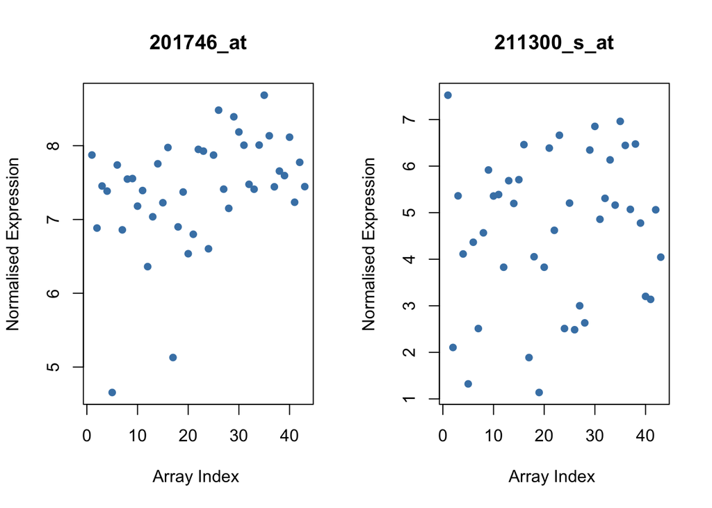

```r
par(mfrow=c(1,2))
plot(E[1274,], xlab="Array Index ",
     col="steelblue",pch=16,
     ylab="Normalised Expression",main="201746_at")

plot(E[10723,], xlab="Array Index ",
     col="steelblue",pch=16,
     ylab="Normalised Expression",main="211300_s_at")
```

Or we could plot one probe against the other

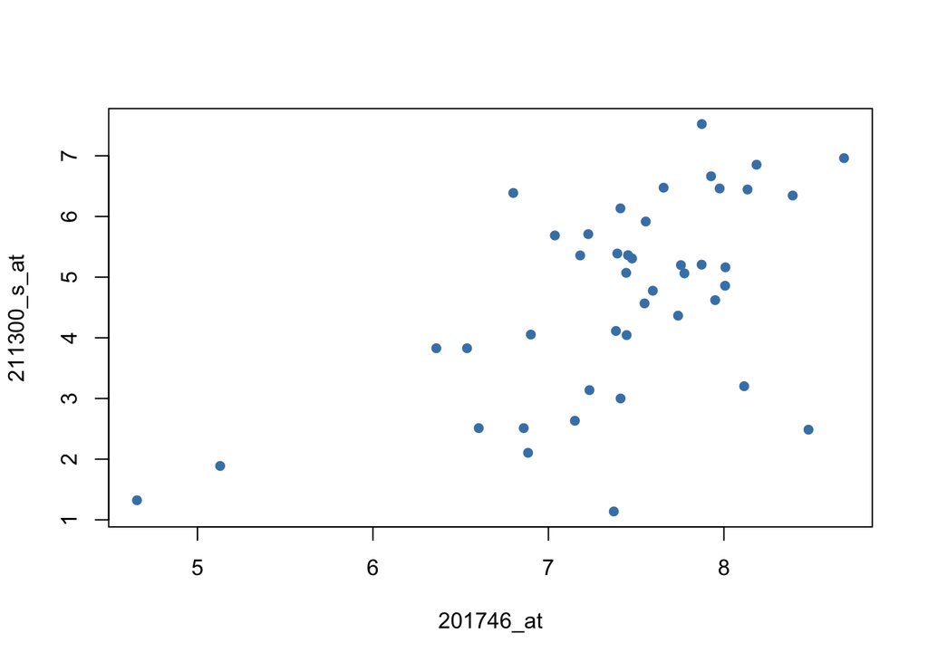

```r
par(mfrow=c(1,1))
plot(E[1274,],E[10723,],xlab="201746_at",ylab="211300_s_at",col="steelblue",pch=16)
```

```r
cor(E[1274,],E[10723,])
```

```
## [1] 0.5691642
```

If we want to include information about the samples on the plot (e.g. clinical variables), then we need to look at how these data are represented in the `ExpressionSet` object. This follows in the next section.

Finally, when deciding which probe to use in the analysis, we could use some of the feature information stored in the `mydata` object. For instance, one probe might represent specific transcript forms of the gene, whereas the other might be more specific.

Another approach would be to use the variability of the probe as a measure of how *informative* it is in the study. The `IQR` (`?IQR`) function can compute this.

```r
IQR(E[1274,])
```

```
## [1] 0.7344926
```

```r
IQR(E[10723,])
```

```
## [1] 2.297881
```

## Example. Dealing with large cohorts

For this second example, we will import a patient cohort

```r
remotefile <- 'ftp://ftp.ncbi.nlm.nih.gov/geo/series/GSE18nnn/GSE18088/matrix/GSE18088_series_matrix.txt.gz'
destfile <- "data/GSE18088_series_matrix.txt.gz"
if(!file.exists(destfile)) download.file(remotefile, destfile)
cohort <- getGEO(filename="data/GSE18088_series_matrix.txt.gz")
```

```
## File stored at:
## /var/folders/b8/q7k4zz6d3x5bxrgwmst1vmmhdbgdr4/T//RtmpfcaJkj/GPL570.soft
```

```r
cohort
```

```
## ExpressionSet (storageMode: lockedEnvironment)
## assayData: 54675 features, 53 samples
##   element names: exprs
## protocolData: none
## phenoData
##   sampleNames: GSM452148 GSM452149 ... GSM452200 (53 total)
##   varLabels: title geo_accession ... data_row_count (36 total)
##   varMetadata: labelDescription
## featureData
##   featureNames: 1007_s_at 1053_at ... AFFX-TrpnX-M_at (54675
##     total)
##   fvarLabels: ID GB_ACC ... Gene Ontology Molecular Function (16
##     total)
##   fvarMetadata: Column Description labelDescription
## experimentData: use 'experimentData(object)'
## Annotation: GPL570
```

As before, we can query the expression matrix and features

```r
head(exprs(cohort)[,1:5])
```

```
##           GSM452148 GSM452149 GSM452150 GSM452151 GSM452152
## 1007_s_at  7.558720  9.126071  8.734507  8.258174  8.481975
## 1053_at    6.750651  6.601878  6.923114  6.938496  7.165163
## 117_at     5.717422  5.605266  5.015487  5.194663  5.120472
## 121_at     6.437157  6.434629  6.392033  6.625201  6.412066
## 1255_g_at  4.078927  3.713068  3.794983  3.681261  3.858806
## 1294_at    6.315349  6.306886  6.049185  6.765942  6.234213
```

```r
head(fData(cohort)[,1:5])
```

```
##                  ID GB_ACC SPOT_ID Species Scientific Name Annotation Date
## 1007_s_at 1007_s_at U48705    <NA>            Homo sapiens     Jun 9, 2011
## 1053_at     1053_at M87338    <NA>            Homo sapiens     Jun 9, 2011
## 117_at       117_at X51757    <NA>            Homo sapiens     Jun 9, 2011
## 121_at       121_at X69699    <NA>            Homo sapiens     Jun 9, 2011
## 1255_g_at 1255_g_at L36861    <NA>            Homo sapiens     Jun 9, 2011
## 1294_at     1294_at L13852    <NA>            Homo sapiens     Jun 9, 2011
```

But an extra feature of this dataset is the availability of clinical information

```r
pData(cohort)[1:5,1:5]
```

```
##           title geo_accession                status submission_date
## GSM452148    C1     GSM452148 Public on Apr 10 2011     Sep 11 2009
## GSM452149    C2     GSM452149 Public on Apr 10 2011     Sep 11 2009
## GSM452150    C3     GSM452150 Public on Apr 10 2011     Sep 11 2009
## GSM452151    C6     GSM452151 Public on Apr 10 2011     Sep 11 2009
## GSM452152    C7     GSM452152 Public on Apr 10 2011     Sep 11 2009
##           last_update_date
## GSM452148      Apr 10 2011
## GSM452149      Apr 10 2011
## GSM452150      Apr 10 2011
## GSM452151      Apr 10 2011
## GSM452152      Apr 10 2011
```

```r
colnames(pData(cohort))
```

```
##  [1] "title"                   "geo_accession"
##  [3] "status"                  "submission_date"
##  [5] "last_update_date"        "type"
##  [7] "channel_count"           "source_name_ch1"
##  [9] "organism_ch1"            "characteristics_ch1"
## [11] "characteristics_ch1.1"   "characteristics_ch1.2"
## [13] "characteristics_ch1.3"   "characteristics_ch1.4"
## [15] "characteristics_ch1.5"   "characteristics_ch1.6"
## [17] "molecule_ch1"            "extract_protocol_ch1"
## [19] "label_ch1"               "label_protocol_ch1"
## [21] "taxid_ch1"               "hyb_protocol"
## [23] "scan_protocol"           "description"
## [25] "data_processing"         "platform_id"
## [27] "contact_name"            "contact_email"
## [29] "contact_department"      "contact_institute"
## [31] "contact_address"         "contact_city"
## [33] "contact_zip/postal_code" "contact_country"
## [35] "supplementary_file"      "data_row_count"
```

```r
pd <- pData(cohort)
View(pd)
```

The interesting columns tend to be in columns starting “characteristics_”

```r
pd[1:4,10:16]
```

```
##              characteristics_ch1 characteristics_ch1.1
## GSM452148 localization: proximal          gender: male
## GSM452149   localization: distal        gender: female
## GSM452150   localization: distal        gender: female
## GSM452151 localization: proximal          gender: male
##           characteristics_ch1.2           characteristics_ch1.3
## GSM452148           relapse: no microsatellite status: MSI-high
## GSM452149           relapse: no      microsatellite status: MSS
## GSM452150           relapse: no      microsatellite status: MSS
## GSM452151           relapse: no      microsatellite status: MSS
##                 characteristics_ch1.4 characteristics_ch1.5
## GSM452148 age at diagnosis, years: 61           grading: G2
## GSM452149 age at diagnosis, years: 65           grading: G3
## GSM452150 age at diagnosis, years: 56           grading: G3
## GSM452151 age at diagnosis, years: 56           grading: G2
##           characteristics_ch1.6
## GSM452148                 pt: 3
## GSM452149                 pt: 3
## GSM452150                 pt: 3
## GSM452151                 pt: 3
```

Q. How many males and females are there in the study? Q. How many of the patients relapsed?

```
##
## gender: female   gender: male
##             27             26
```

```
##
##  relapse: no relapse: yes
##           40           13
```

This cateogorical information can be used in our analysis.

Lets take the gene *XIST* and find what probes target this gene;

```r
rows <- which(fData(cohort)$"Gene Symbol" == "XIST")
rows
```

```
## [1] 23518 31009 33848 33849 33850 36926 44696 52962
```

If we take just the first probe, it clearly exhibits bi-modal behaviour.

```r
subset <- exprs(cohort)[rows,]
dim(subset)
```

```
## [1]  8 53
```

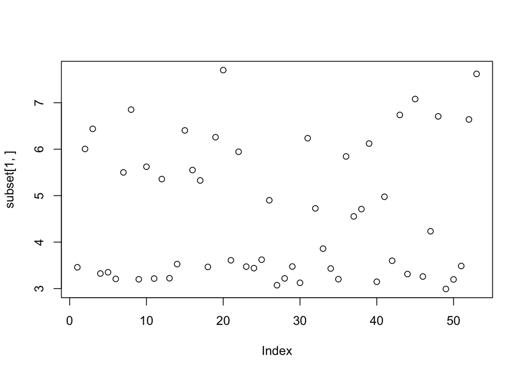

```r
plot(subset[1,])
```

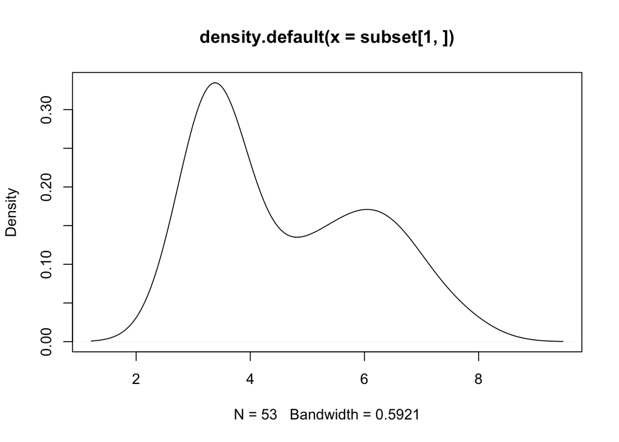

```r
plot(density(subset[1,]))
```

A boxplot using the gender of the samples is very informative

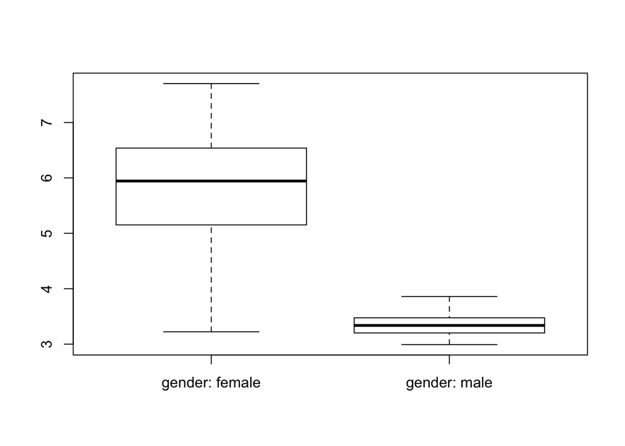

```r
boxplot(subset[1,]~pd$characteristics_ch1.1)
```

*N.B. we haven’t discussed looping in R yet, so here is the long-hand way to produce these plots*

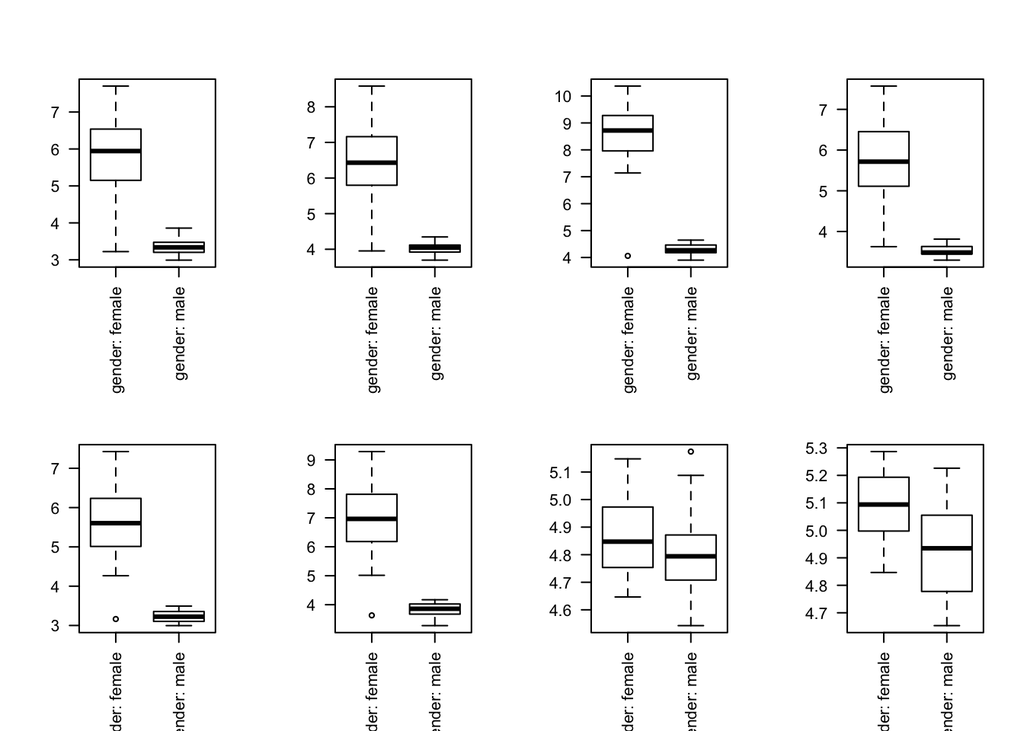

```r
par(mfrow=c(2,4))
boxplot(subset[1,]~pd$characteristics_ch1.1,las=2)
boxplot(subset[2,]~pd$characteristics_ch1.1,las=2)
boxplot(subset[3,]~pd$characteristics_ch1.1,las=2)
boxplot(subset[4,]~pd$characteristics_ch1.1,las=2)
boxplot(subset[5,]~pd$characteristics_ch1.1,las=2)
boxplot(subset[6,]~pd$characteristics_ch1.1,las=2)
boxplot(subset[7,]~pd$characteristics_ch1.1,las=2)
boxplot(subset[8,]~pd$characteristics_ch1.1,las=2)
```

## Example: Extra manipulation of the clinical data

Q. What is the age distribution of the samples?

[figure not shown]

This is trickier without extra manipulation of the data. R supports various string-cleaning operations such as substituting text, trimming etc. A commonly-used function is `gsub` (`?gsub`) which replaces a given *pattern* with a *replacement* string for every element in a character vector. In this case, we want to replace `age at diagnosis, years:` with the blank string `""`. The R code is thus;

```r
clinvars <- pd[,10:16]
gsub("age at diagnosis, years: ","",clinvars$characteristics_ch1.4)
```

```
##  [1] "61" "65" "56" "56" "74" "56" "75" "75" "58" "75" "68" "72" "59" "66"
## [15] "70" "74" "60" "74" "71" "84" "60" "85" "71" "65" "66" "73" "78" "34"
## [29] "49" "81" "55" "77" "49" "83" "56" "59" "46" "64" "65" "63" "43" "85"
## [43] "82" "62" "70" "71" "40" "73" "81" "40" "62" "70" "61"
```

However, R still treats the result as a character vector (as each item has `""` around it). We need to explicitly convert to numeric values before proceeding

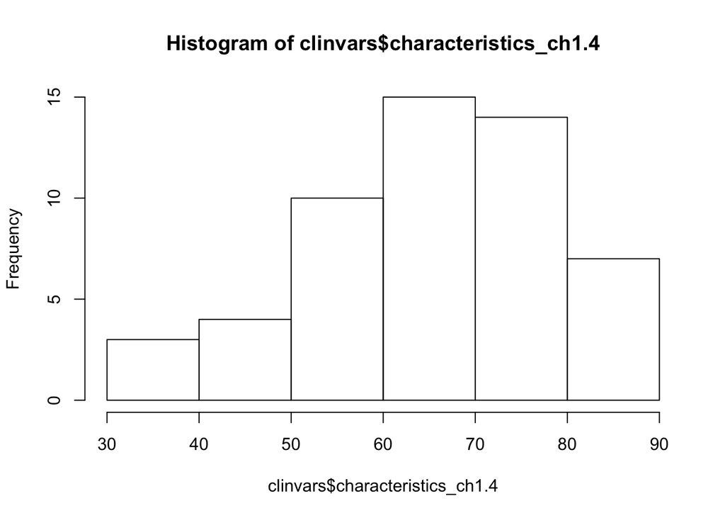

```r
clinvars$characteristics_ch1.4 <- as.numeric(gsub("age at diagnosis, years: ","",clinvars$characteristics_ch1.4))
hist(clinvars$characteristics_ch1.4)
```

Q. Clean-up the gender column so that the values are either `male` or `female`.

```
## sex
## female   male
##     27     26
```

```r
nchar(as.character(clinvars$characteristics_ch1.1))
```

```
##  [1] 12 14 14 12 12 12 14 14 12 14 12 14 14 12 14 14 14 12 14 14 12 14 12
## [24] 12 12 14 12 12 12 12 14 14 12 12 12 14 14 14 14 12 14 12 14 12 14 12
## [47] 14 14 12 12 12 14 14
```

```r
sex <- substr(clinvars$characteristics_ch1.1,9,nchar(as.character(clinvars$characteristics_ch1.1)))
sex
```

```
##  [1] "male"   "female" "female" "male"   "male"   "male"   "female"
##  [8] "female" "male"   "female" "male"   "female" "female" "male"
## [15] "female" "female" "female" "male"   "female" "female" "male"
## [22] "female" "male"   "male"   "male"   "female" "male"   "male"
## [29] "male"   "male"   "female" "female" "male"   "male"   "male"
## [36] "female" "female" "female" "female" "male"   "female" "male"
## [43] "female" "male"   "female" "male"   "female" "female" "male"
## [50] "male"   "male"   "female" "female"
```

# Appendix

## Supplementary data from GEO

Example from the Bioconductor course in [Montevideo, Uruguay](http://bioconductor.org/help/course-materials/2015/Uruguay2015/)

We can also download supplementary files from GEO. In the case of Affymetrix arrays, this may include the *.CEL* files

```r
x = getGEOSuppFiles("GSE20986")
```

```
## ftp://ftp.ncbi.nlm.nih.gov/geo/series/GSE20nnn/GSE20986/suppl/
```

```r
x
```

```
##                                                                            size
## /Users/dunnin01/work/git/microarray-analysis/GSE20986/GSE20986_RAW.tar 56360960
## /Users/dunnin01/work/git/microarray-analysis/GSE20986/filelist.txt          740
##                                                                        isdir
## /Users/dunnin01/work/git/microarray-analysis/GSE20986/GSE20986_RAW.tar FALSE
## /Users/dunnin01/work/git/microarray-analysis/GSE20986/filelist.txt     FALSE
##                                                                        mode
## /Users/dunnin01/work/git/microarray-analysis/GSE20986/GSE20986_RAW.tar  664
## /Users/dunnin01/work/git/microarray-analysis/GSE20986/filelist.txt      664
##                                                                                      mtime
## /Users/dunnin01/work/git/microarray-analysis/GSE20986/GSE20986_RAW.tar 2016-02-14 11:07:22
## /Users/dunnin01/work/git/microarray-analysis/GSE20986/filelist.txt     2016-02-14 11:07:26
##                                                                                      ctime
## /Users/dunnin01/work/git/microarray-analysis/GSE20986/GSE20986_RAW.tar 2016-02-14 11:07:22
## /Users/dunnin01/work/git/microarray-analysis/GSE20986/filelist.txt     2016-02-14 11:07:26
##                                                                                      atime
## /Users/dunnin01/work/git/microarray-analysis/GSE20986/GSE20986_RAW.tar 2016-02-14 11:07:25
## /Users/dunnin01/work/git/microarray-analysis/GSE20986/filelist.txt     2016-02-14 11:07:26
##                                                                              uid
## /Users/dunnin01/work/git/microarray-analysis/GSE20986/GSE20986_RAW.tar 448247556
## /Users/dunnin01/work/git/microarray-analysis/GSE20986/filelist.txt     448247556
##                                                                         gid
## /Users/dunnin01/work/git/microarray-analysis/GSE20986/GSE20986_RAW.tar 1329
## /Users/dunnin01/work/git/microarray-analysis/GSE20986/filelist.txt     1329
##                                                                           uname
## /Users/dunnin01/work/git/microarray-analysis/GSE20986/GSE20986_RAW.tar dunnin01
## /Users/dunnin01/work/git/microarray-analysis/GSE20986/filelist.txt     dunnin01
##                                                                                         grname
## /Users/dunnin01/work/git/microarray-analysis/GSE20986/GSE20986_RAW.tar unix-bioinformatics-foo
## /Users/dunnin01/work/git/microarray-analysis/GSE20986/filelist.txt     unix-bioinformatics-foo
```

The supplementary file comes as a *tar* archive, which we need to extract to get the individual cel files.

```r
untar("GSE20986/GSE20986_RAW.tar", exdir = "suppdata")
list.files("suppdata/")
```

```
##  [1] "GSM524662.CEL"    "GSM524662.CEL.gz" "GSM524663.CEL"
##  [4] "GSM524663.CEL.gz" "GSM524664.CEL"    "GSM524664.CEL.gz"
##  [7] "GSM524665.CEL"    "GSM524665.CEL.gz" "GSM524666.CEL"
## [10] "GSM524666.CEL.gz" "GSM524667.CEL"    "GSM524667.CEL.gz"
## [13] "GSM524668.CEL"    "GSM524668.CEL.gz" "GSM524669.CEL"
## [16] "GSM524669.CEL.gz" "GSM524670.CEL"    "GSM524670.CEL.gz"
## [19] "GSM524671.CEL"    "GSM524671.CEL.gz" "GSM524672.CEL"
## [22] "GSM524672.CEL.gz" "GSM524673.CEL"    "GSM524673.CEL.gz"
```

Each cel file is zipped, so we unzip with *gunzip*.

```r
cels = list.files("suppdata/", pattern = "[gz]")
sapply(paste("suppdata", cels, sep = "/"), gunzip)
```

```
## suppdata/GSM524662.CEL.gz suppdata/GSM524663.CEL.gz
##                  13555726                  13555055
## suppdata/GSM524664.CEL.gz suppdata/GSM524665.CEL.gz
##                  13555639                  13560122
## suppdata/GSM524666.CEL.gz suppdata/GSM524667.CEL.gz
##                  13555663                  13557614
## suppdata/GSM524668.CEL.gz suppdata/GSM524669.CEL.gz
##                  13556090                  13560054
## suppdata/GSM524670.CEL.gz suppdata/GSM524671.CEL.gz
##                  13555971                  13554926
## suppdata/GSM524672.CEL.gz suppdata/GSM524673.CEL.gz
##                  13555042                  13555290
```

We can now proceed as with the Affymetrix workflow.

```r
library(affy)
raw <- ReadAffy(celfile.path = "suppdata/")
raw
```

```
## AffyBatch object
## size of arrays=1164x1164 features (20 kb)
## cdf=HG-U133_Plus_2 (54675 affyids)
## number of samples=12
## number of genes=54675
## annotation=hgu133plus2
## notes=
```

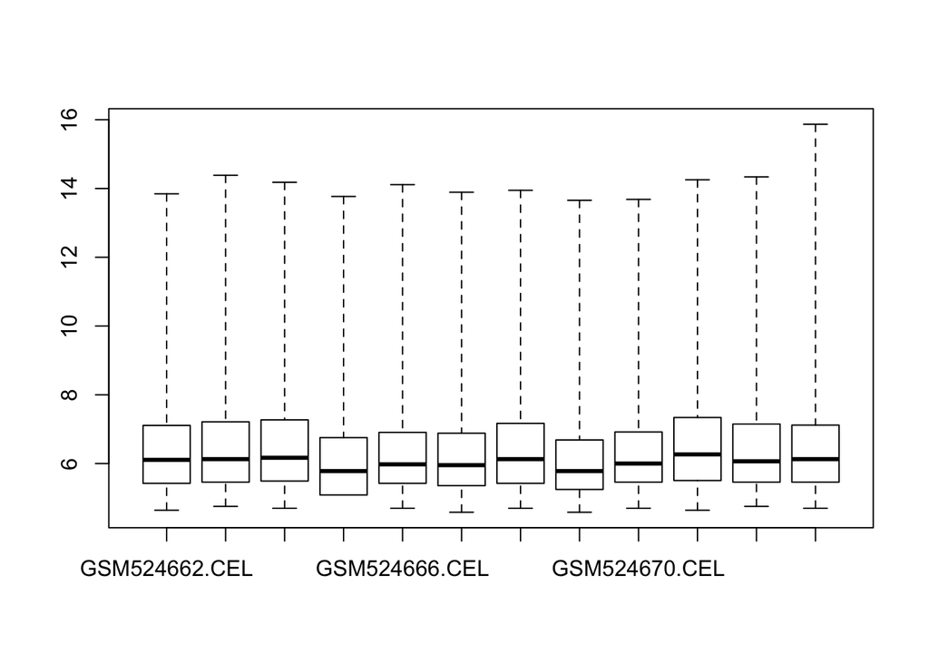

```r
boxplot(raw)
```

## Data in ArrayExpress

The ArrayExpress vignette has various examples of importing data from the *ArrayExpress* repository into R. Similar to `getGEO` from `GEOquery`, the `getAE` function can do the import if the accession number is known. If we want just normalised data, we set an argument `type=processed`.

```r
library(ArrayExpress)
mydata <- getAE("E-GEOD-69017",type="processed")
```

```
## Copying processed data files
##
## Unpacking data files
```

```r
mydata
```

```
## $path
## [1] "/Users/dunnin01/work/git/microarray-analysis"
##
## $rawFiles
## NULL
##
## $rawArchive
## NULL
##
## $processedFiles
##  [1] "GSM1690180_sample_table.txt" "GSM1690179_sample_table.txt"
##  [3] "GSM1690178_sample_table.txt" "GSM1690177_sample_table.txt"
##  [5] "GSM1690176_sample_table.txt" "GSM1690175_sample_table.txt"
##  [7] "GSM1690174_sample_table.txt" "GSM1690173_sample_table.txt"
##  [9] "GSM1690172_sample_table.txt" "GSM1690171_sample_table.txt"
## [11] "GSM1690170_sample_table.txt" "GSM1690169_sample_table.txt"
## [13] "GSM1690168_sample_table.txt" "GSM1690167_sample_table.txt"
## [15] "GSM1690166_sample_table.txt" "GSM1690165_sample_table.txt"
## [17] "GSM1690164_sample_table.txt" "GSM1690163_sample_table.txt"
## [19] "GSM1690162_sample_table.txt" "GSM1690161_sample_table.txt"
## [21] "GSM1690160_sample_table.txt" "GSM1690159_sample_table.txt"
## [23] "GSM1690158_sample_table.txt" "GSM1690157_sample_table.txt"
## [25] "GSM1690156_sample_table.txt" "GSM1690155_sample_table.txt"
## [27] "GSM1690154_sample_table.txt" "GSM1690153_sample_table.txt"
## [29] "GSM1690152_sample_table.txt" "GSM1690151_sample_table.txt"
## [31] "GSM1690150_sample_table.txt" "GSM1690149_sample_table.txt"
## [33] "GSM1690148_sample_table.txt" "GSM1690147_sample_table.txt"
## [35] "GSM1690146_sample_table.txt" "GSM1690145_sample_table.txt"
## [37] "GSM1690144_sample_table.txt" "GSM1690143_sample_table.txt"
## [39] "GSM1690142_sample_table.txt" "GSM1690141_sample_table.txt"
## [41] "GSM1690140_sample_table.txt" "GSM1690139_sample_table.txt"
## [43] "GSM1690138_sample_table.txt" "GSM1690137_sample_table.txt"
## [45] "GSM1690136_sample_table.txt" "GSM1690135_sample_table.txt"
## [47] "GSM1690134_sample_table.txt" "GSM1690133_sample_table.txt"
## [49] "GSM1690132_sample_table.txt" "GSM1690131_sample_table.txt"
## [51] "GSM1690130_sample_table.txt"
##
## $processedArchive
## [1] "E-GEOD-69017.processed.1.zip"
##
## $sdrf
## [1] "E-GEOD-69017.sdrf.txt"
##
## $idf
## [1] "E-GEOD-69017.idf.txt"
##
## $adf
## [1] "A-AFFY-33.adf.txt"
```

Alternatively, we can get the full dataset (including raw cel files) with `type=full`.

```r
rawdata <- getAE("E-GEOD-69017",type="full")
```

```
## Copying raw data files
##
## Copying processed data files
##
## Unpacking data files
```

We can process the *cel* files using the Affymetrix workflow, or `ArrayExpress` can process them for us.

```r
procdata <- ae2bioc(rawdata)
```

```
## ArrayExpress: Reading pheno data from SDRF
## ArrayExpress: Reading data files
```